*<-- Click the "Show Code" button to view/hide code.*

#### Thinkful Data Science Bootcamp - Prep Course Capstone Project

#### Coded by Emile Badran on January-2018

# Cryptocurrencies

The cryptocurrency market is in frenzy. Journalists from major news outlets such as [CNN](http://money.cnn.com/2017/12/07/investing/bitcoin-what-is-going-on/index.html) and [The Economist](https://www.economist.com/news/leaders/21731161-there-ico-bubble-it-holds-out-promise-something-important-meaning) seem to agree. Warren Buffett, the billionaire investor, says that cryptocurrencies will "[almost certainly come to a bad ending](https://www.theguardian.com/technology/2018/jan/10/bitcoin-and-cryptocurrencies-will-come-to-a-bad-end-says-warren-buffett)." The first cryptocurrency, Bitcoin was created in 2009 with [basically no value](https://en.wikipedia.org/wiki/History_of_bitcoin). By January 2017, it was worth almost USD 1,000 and soared to USD 17,000 by December. Other digital currencies such as Ethereum and Bitcoin-cash have had [even steeper climbs](https://www.bloomberg.com/gadfly/articles/2017-12-28/bitcoin-s-store-of-value-is-eroded-by-rivals-like-ethereum).

While critics call them a bubble, enthusiasts claim that cryptocurrencies may serve as alternatives to gold and fiat currency as *stores of value*. The Bitcoin Foundation (a non-profit with the mission of creating awareness of the benefits of the currency) has [published a manifesto](https://bitcoinfoundation.org/wp-content/uploads/2017/03/Bitcoin_Foundation_Manifesto.pdf) stating that "fiat currency has been a poor long-term store of value, especially since the gold standard was abolished."

By [definition](https://en.wikipedia.org/wiki/Store_of_value), a store of value is any form of asset that retains purchasing power into the future. The US Dollar, gold, stock market shares, and original artwork are all examples of popular stores of value. [Desirable characteristics](https://www.investopedia.com/terms/s/storeofvalue.asp) of stores of value are stability (in terms of their price against other stores of value) and liquidity (whether they can be easily exchanged for other goods and services).

But have cryptocurrencies lived up to the promise of being better stores of value than traditional assets? Specifically, have other cryptocurrencies with relevant market share seen soaring value growth? Are there any relatively stable cryptocurrency options? How does Bitcoin and other digital currencies compare to the US Dollar, gold, and stock markets?

To gain insight into these questions, this short report looks into historical cryptocurrency prices and analizes the variance of their daily rates against gold prices in US Dollars. The report also compares the market size of cryptocurrencies against the US Stock Market, and tracks the number of cryptocurrencies created since April/2013. Finally, the report will verify whether or not the value of Bitcoin is correlated with the value of gold.

## About the dataset

The dataset analyzed for this report was obtained from three sources.

#### Data source #1: Cryptocurrency market data

The cryptocurrency data was originally compiled and published by Jesse Vent onto a [Kaggle dataset](https://www.kaggle.com/jessevent/all-crypto-currencies/data). The data file was downloaded on 24/January/2018. It contains the daily market capital worth, volume exchanged, and opening and closing values of 1,400 cryptocurrencies. It is comprised of 659,373 observations ranging from April 28, 2013, to January 10, 2018.

```python
import pandas as pd
import numpy as np
from random import *
import matplotlib.pyplot as plt
import squarify
import plotly
from plotly.graph_objs import *
import plotly.graph_objs as go
plotly.offline.init_notebook_mode()

cc = pd.read_csv('cryptocurrencies.csv')

# Drop unnecessary variables:
cc = cc.drop(['symbol','volume','spread'], axis=1)

# Convert the 'date' column values into datetime objects:
cc.loc[:,'date'] = pd.to_datetime(cc.loc[:,'date'])
cc.head(3)
```

|  | slug | date | ranknow | open | high | low | close | market |
| --- | --- | --- | --- | --- | --- | --- | --- | --- |
| 0 | bitcoin | 2013-04-28 | 1 | 135.30 | 135.98 | 132.10 | 134.21 | 1500520000 |
| 1 | bitcoin | 2013-04-29 | 1 | 134.44 | 147.49 | 134.00 | 144.54 | 1491160000 |
| 2 | bitcoin | 2013-04-30 | 1 | 144.00 | 146.93 | 134.05 | 139.00 | 1597780000 |

Column metadata:

- slug: The cryptocurrency's name
- date: The date for that trade
- ranknow: The current rank of the cryptocurrency in terms of its market value
- open: The amount in US Dollars that the day started at
- high: The highest exchange value it got to in US dollars that day
- low: The lowest exchange value it got to in US dollars that day
- close: The exchange value in US dollars that the day finished at
- market: The total amount of market capital (combined worth) in US dollars

#### Data Source #2 - Gold prices

The gold price data is based on prices from the London Bullion Market Authority ([LBMA](http://www.lbma.org.uk/)), and was obtained from [Quandl](https://www.quandl.com/collections/markets/gold), an online repository for financial data. The LBMA fixes the price of gold by matching gold buyers and gold sellers until the market clears. These gold prices are considered the benchmark for gold trading around the world.

```python
gd = pd.read_csv('LBMA-GOLD.csv')

# Drop unnecessary columns:
gd = gd.drop(['USD (AM)', 'GBP (AM)', 'GBP (PM)', 'EURO (AM)', 'EURO (PM)'], axis=1)

# Convert Date column to datetime objects, then filter dates within desired period:
gd.loc[:,'Date'] = pd.to_datetime(gd.loc[:,'Date'])
gd = gd[gd['Date'].isin(pd.date_range('2017-1-3', '2018-1-10'))]

# Use set_index() to convert 'Date' column to index, then resample() to create missing (weekend) date rows.
gd.set_index('Date', drop=False, inplace=True)
gd = gd.resample('D').mean()

# Fill NaN values with the previous non-null value:
gd['USD (PM)'] = gd['USD (PM)'].fillna(method='ffill')

# Reset the index and convert "Date" into a column:
gd.reset_index(level=0, inplace=True)

# To maintain consistency across all metadata, rename columns to lower case and to "close":
gd.rename(columns={'Date':'date', 'USD (PM)':'close'}, inplace=True)
gd.head(3)
```

|  | date | close |
| --- | --- | --- |
| 0 | 2017-01-03 | 1151.00 |
| 1 | 2017-01-04 | 1164.25 |
| 2 | 2017-01-05 | 1176.70 |

Column metadata:

- date: The date for that trade
- close: The exchange value in US dollars that the day finished at

#### Data source #3 - US stock market values

Finally, US stock market values were obtained from the latest [monthly report](https://www.world-exchanges.org/home/index.php/statistics/monthly-reports) from The World Federation of Exchanges (WFE) a non-profit association of global exchanges that compiles market data statistics.

The columns represent the monthly total capitalization values of the NASDAQ and the New York Stock Exchange (NYSE) markets.

```python
# Read the CSV file. Ignore the commas in numbers with thousands separators:
sm = pd.read_csv('total_stock_market_capitalization.csv', thousands=',')

# Transpose rows and columns:
sm = sm.transpose()

# Rename column indexes with values from the first row:
sm = sm.rename(columns=sm.iloc[0])

# Delete the first row with column names:
sm.drop(sm.index[0], inplace=True)

# Reset row indexes. Since the original indexes had months names as strings, drop their values:
sm = sm.reset_index(level=0, drop=True)

# Create a 'date' column with datetime values of the last day of each month:
sm.insert(loc=0, column='date', value=pd.date_range('1/1/2017', periods=11, freq='M'))

# Convert dtype of remaining columns to float:
sm['NYSE'] = sm['NYSE'].astype(float, copy=False)
sm['Nasdaq - US'] = sm['Nasdaq - US'].astype(float, copy=False)
sm.head(3)
```

|  | date | Nasdaq - US | NYSE |
| --- | --- | --- | --- |
| 0 | 2017-01-31 | 8.125737e+12 | 1.959664e+13 |
| 1 | 2017-02-28 | 8.348219e+12 | 2.043156e+13 |
| 2 | 2017-03-31 | 8.436062e+12 | 2.001162e+13 |

## Market size

Let's start by summing the total amount of market capitalization (also known as "market cap" or "market value") of all cryptocurrencies, and plotting a bar chart to compare the size of this market against the US Stock Market.

```python
# Sum the total amount of market capitalization of all cryptocurrencies and create a bar
# plot comparing the market values of all cryptocurrencies with the NYSE.

cc_mkt_size_30_nov = cc.loc[lambda df: cc['date']=='2017-11-30', :]['market'].sum()
nyse_mkt_size_30_nov = int(sm.loc[lambda df: sm['date']=='2017-11-30', :]['NYSE'])
nasdaq_mkt_size_30_nov = int(sm.loc[lambda df: sm['date']=='2017-11-30', :]['Nasdaq - US'])

assets = [cc_mkt_size_30_nov, nasdaq_mkt_size_30_nov, nyse_mkt_size_30_nov]
names = ['All Cryptocurrencies', 'NASDAQ', 'NYSE']

trace0 = go.Bar(
    x=names,
    y=assets,
    marker=dict(
        color='rgb(158,202,225)',
        line=dict(
            color='rgb(110,20,110)',
            width=1.5,
        )
    ),
    opacity=0.6
)

data = [trace0]

layout = {
  'yaxis': {'title': 'Market Capitalization (USD Trillion)'},
  'barmode': 'relative',
  'title': 'Total Market Capitalization in 30 November, 2017'
};

fig = go.Figure(data=data, layout=layout)
plotly.offline.iplot(fig)
```

[interactive chart not shown]

The difference in the bar sizes can be misleading. Cryptocurrencies have only existed for a few years, and by November 30th, 2017 their market worth was already nearing USD 300 billion (and growing).

The next bar plot shows an exponential growth in the number of distinct cryptocurrencies over time. While there were only six digital currencies in May 2013, as of January 2018 the number has sprung to more than 1,400.

```python
# Count the number of cryptocurrencies according to dates when new currencies were created:
cc_counts = cc.groupby('date').slug.count()

# Plot the bar chart:
trace0 = go.Bar(
    x=cc_counts.index,
    y=cc_counts.values,
    marker=dict(
        color='rgb(158,202,100)',
        line=dict(
            color='rgb(110,20,110)',
            width=1.5,
        )
    ),
    opacity=0.6
)

data = [trace0]

layout = {
  'xaxis': {'title': 'Date'},
  'yaxis': {'title': 'Number of Cryptocurrencies'},
  'barmode': 'relative',
  'title': 'Growth in the Number of Cryptocurrencies'
};

# Generate the plot figure:
fig = go.Figure(data=data, layout=layout)

# Call the plot. Plotly is free of charge when used in offline mode =]
plotly.offline.iplot(fig)
```

[interactive chart not shown]

With so many cryptocurrencies being created, one would expect that many of the newer currencies have minimal market value. The following treemap graph helps us compare the market value sizes of the 30 largest cryptocurrencies.

Notice that among the 30 largest, more than 3/4 of the market cap is concentrated on five currencies. Henceforth, this report will focus the analysis on these five currencies.

```python
# Filter rows from January 10, 2017:
cc_jan_18 = cc.loc[lambda df: cc['date']=='2018-1-10']

# Filter the thirty currencies with highest market values in January 10, 2018:
top_thirty = cc_jan_18.loc[lambda df: cc_jan_18['ranknow']<=30, :]

tt = top_thirty.groupby('slug').market.sum()
tt = tt.sort_values(ascending=False)
```

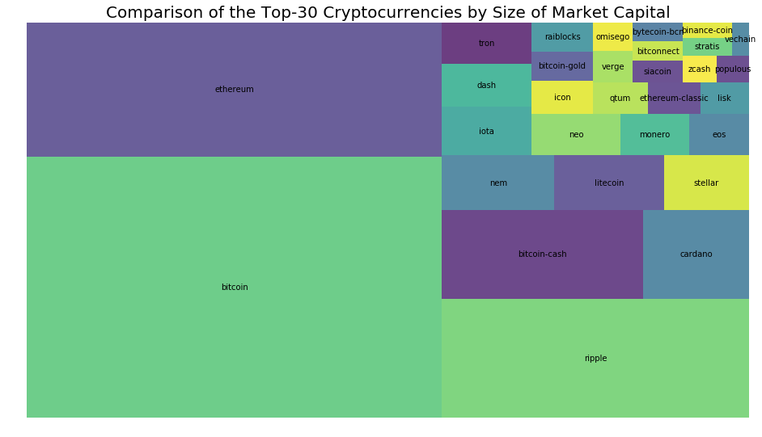

```python
plt.figure(figsize=(16, 9))
squarify.plot(sizes=tt.values, label=tt.index, alpha=.8 )
plt.axis('off')
plt.title("Comparison of the Top-30 Cryptocurrencies by Size of Market Capital", fontsize=20)
plt.show()
```

## Currency values

On the next graph, we can see the five cryptocurrencies with largest market value have also seen exponential growth. Note that the graph depicts each currency by a shaded line. The "shades" represent the difference between the highest and lowest values of the day (zoom in the graph to see in more detail).

Note - the next plots are made with Plotly, an open source interactive graphing library:

- Click-and-drag the chart area to zoom in. Double-click the chart area to zoom out.
- Double-click the legend to isolate currency.
- Drag the x and y labels to pan the chart.

```python
# Filter all rows starting from January 3, 2017:
cc_17_18 = cc.loc[lambda df: cc['date']>='2017-1-3']

# Filter the five currencies with highest market values in January 10, 2018:
top_five = cc_17_18.loc[lambda df: cc_17_18['ranknow']<=5, :]

# Create a dictionary in which each key/value item is a dataframe
# containing data from a single currency:
df_dict = {i : pd.DataFrame for i in top_five['slug']}
for key in df_dict.keys():
    df_dict[key] = top_five[:][top_five['slug'] == key]

# Plot all five currencies on a line chart. This function creates a set of three lines
# for any number of currencies contained in the df_dict DataFrame. The "closing" value
# is represented as a colored line, and the "high" and "low" values are represented as
# transparent, filled lines. The function also generates random colors for every line:
def create_traces(df_dict):
    data_list = []
    for i in df_dict:
        randnum1 = randint(20,250)
        randnum2 = randint(20,250)
        randnum3 = randint(20,250)
        trace1=Scatter(
            x=df_dict[i]['date'],
            y=df_dict[i]['high'],
            line=Line(color='transparent'),
            mode='lines',
            showlegend=False,
            hoverinfo='skip',
            name='{} high'.format(i),
        )
        trace2=Scatter(
            x=df_dict[i]['date'],
            y=df_dict[i]['low'],
            line=Line(color='transparent'),
            fillcolor='rgba({},{},{},.3)'.format(randnum1,randnum2,randnum3),
            mode='lines',
            fill='tonexty',
            showlegend=False,
            hoverinfo='skip',
            name= '{} low'.format(i),
        )
        trace3=Scatter(
            x=df_dict[i]['date'],
            y=df_dict[i]['close'],
            line=Line(color='rgb({},{},{})'.format(randnum1,randnum2,randnum3)),
            mode='lines',
            name='{}'.format(i),
        )
        data_list.append(trace1)
        data_list.append(trace2)
        data_list.append(trace3)
    return data_list

data = Data(create_traces(df_dict))

layout = Layout(
    title='Cryptocurrency Daily Values',
    paper_bgcolor='rgb(255,255,255)',
    plot_bgcolor='rgb(255,255,255)',
    xaxis=XAxis(
        gridcolor='rgb(255,255,255)',
        showgrid=True,
        showline=False,
        showticklabels=True,
        tickcolor='rgb(127,127,127)',
        ticks='outside',
        zeroline=False
    ),
    yaxis=YAxis(
        title='Value in US Dollars',
        gridcolor='rgb(230,230,230)',
        showgrid=True,
        showline=False,
        showticklabels=True,
        tickcolor='rgb(127,127,127)',
        ticks='outside',
        zeroline=False
    ),
    margin=dict(
    l=50,
    r=30,
    b=80,
    t=100,
    ),
)
fig = Figure(data=data, layout=layout)
plotly.offline.iplot(fig)
```

[interactive chart not shown]

## Variance

Although the increase in value is impressive, the spikes and valleys indicate high volatility (or high variance) in currency prices. Nevertheless, many fiat currencies and stock markets are notoriously volatile.

Let's generate a set of box (sub)plots to better assess the variance of each of our cryptocurrencies and compare them against gold and the US Stock Market. Since the Stock Market values are so much higher in magnitude, the asset values will be normalized.

```python
# Create separate DataFrames for nyse and nasdaq values with consistent column names:
nyse = sm.loc[:,('date','NYSE')]
nasdaq = sm.loc[:,('date','Nasdaq - US')]
nasdaq.rename(columns={'Nasdaq - US':'close'}, inplace=True)
nyse.rename(columns={'NYSE':'close'}, inplace=True)

# Normalize gold, nasdaq and nyse values:
gd['norm'] = ((gd['close'] - gd['close'].mean())
              / (gd['close'].max() - gd['close'].min()))
nasdaq['norm'] = ((nasdaq['close'] - nasdaq['close'].mean())
                  / (nasdaq['close'].max() - nasdaq['close'].min()))
nyse['norm'] = ((nyse['close'] - nyse['close'].mean())
                / (nyse['close'].max() - nyse['close'].min()))

# Normalize the close values of Bitcoin, Ethereum, Ripple and Bitcoin-cash:
for i in df_dict:
    df_dict[i]['norm'] = ((df_dict[i]['close'] - df_dict[i]['close'].mean())
                          / (df_dict[i]['close'].max() - df_dict[i]['close'].min()))
```

```python
# Create boxplots of the normalized closing values of each store of value:
x_data = ['Bitcoin', 'Bitcoin-Cash',
          'Ethereum', 'Ripple','Gold','NYSE','NASDAQ']

y0 = df_dict['bitcoin']['norm']
y1 = df_dict['bitcoin-cash']['norm']
y2 = df_dict['ethereum']['norm']
y3 = df_dict['ripple']['norm']
y4 = gd['norm']
y5 = nyse['norm']
y6 = nasdaq['norm']

y_data = [y0,y1,y2,y3,y4,y5,y6]

colors = [
    'rgba(80,140,230,0.5)','rgba(240,130,10,0.5)','rgba(40,180,90,0.5)',
    'rgba(255,65,55,0.5)','rgba(200,110,255,0.5)','rgba(30,60,90,0.5)',
    'rgba(125,25,70,0.5)'
]

traces = []

for xd, yd, cls in zip(x_data, y_data, colors):
    traces.append(go.Box(
        y=yd,
        name=xd,
        boxpoints='all',
        jitter=0.5,
        whiskerwidth=0.2,
        fillcolor=cls,
        marker=dict(
            size=2,
        ),
        line=dict(width=1),
    )
)

layout = go.Layout(
    title='Asset Values (US$ Normalized)',
    yaxis=dict(
        autorange=True,
        showgrid=True,
        zeroline=True,
        showticklabels=True,
        gridcolor='rgb(230,230,230)',
        gridwidth=1,
        zerolinecolor='rgb(255, 255, 255)',
        zerolinewidth=2,
    ),
    xaxis=dict(
        title='From 3/January/2017 to 10/January/2018'),
    margin=dict(
        l=50,
        r=30,
        b=80,
        t=100,
    ),
    paper_bgcolor='rgb(255, 255, 255)',
    plot_bgcolor='rgb(255, 255, 255)',
    showlegend=True
)

fig = go.Figure(data=traces, layout=layout)
plotly.offline.iplot(fig)
```

[interactive chart not shown]

The rapid growth of digital currencies can be noticed by how the outliers are all located on their plots' upper whiskers. Of all assets, Ripple has demonstrated the least variance and the furthest reaching outliers, an evidence of its sudden, fast growth.

Now that the values are normalized, let's look in more detail at the assets' descriptive statistics:

```python
# Create a DataFrame with descriptions of the normalized values of each store of value:
describe_df = pd.DataFrame(
    {'bitcoin': df_dict['bitcoin']['norm'].describe(),
     'bitcoin-cash': df_dict['bitcoin-cash']['norm'].describe(),
     'ethereum': df_dict['ethereum']['norm'].describe(),
     'ripple': df_dict['ripple']['norm'].describe(),
     'gold': gd['norm'].describe(),
     'nyse': nyse['norm'].describe(),
     'nasdaq': nasdaq['norm'].describe()
    }
)

# Set how Pandas displays floats, to supress scientific notation:
pd.set_option('display.float_format',lambda x: '%.3f' % x)
# Visualize the DataFrame with descriptive statistics of each store of value:
print('\n\n     Descriptive Statistics (USD Normalized Values)')
describe_df
```

```
     Descriptive Statistics (USD Normalized Values)
```

|  | bitcoin | bitcoin-cash | ethereum | gold | nasdaq | nyse | ripple |
| --- | --- | --- | --- | --- | --- | --- | --- |
| count | 373.000 | 172.000 | 373.000 | 373.000 | 11.000 | 11.000 | 373.000 |
| mean | 0.000 | -0.000 | 0.000 | 0.000 | -0.000 | -0.000 | 0.000 |
| std | 0.236 | 0.228 | 0.177 | 0.179 | 0.312 | 0.286 | 0.147 |
| min | -0.190 | -0.210 | -0.184 | -0.555 | -0.466 | -0.455 | -0.079 |
| 25% | -0.167 | -0.164 | -0.154 | -0.106 | -0.224 | -0.163 | -0.071 |
| 50% | -0.090 | -0.109 | 0.004 | 0.017 | -0.047 | -0.024 | -0.022 |
| 75% | 0.024 | 0.117 | 0.054 | 0.122 | 0.184 | 0.142 | -0.006 |
| max | 0.810 | 0.790 | 0.816 | 0.445 | 0.534 | 0.545 | 0.921 |

Notice how close the minimum values of cryptocurrencies are from the mean; and in contrast, how far their maximum values are. Also noteworthy is how Ripple has achieved the highest maximum value, despite having the lowest standard deviation. This indicates that among these assets, Ripple has had, in absolute values, the fastest growth. And once again, the NASDAQ and NYSE are the assets with the highest standard deviations.

```python
# Reset the float format to its original setting:
pd.reset_option('display.float_format')
```

### Correlation

Gold has the reputation of being a safe haven for capital in times of economic distress - the reason being that it has historically been [negatively correlated](https://www.hardassetsalliance.com/blog/why-gold-will-save-your-portfolio-in-the-upcoming-recession?utm_campaign=HA-055&utm_medium=ED&utm_source=for#.WnECYoJOnOR) to stocks and other forms of investment.

[Asset correlation](https://www.thebalance.com/what-is-asset-correlation-2894312) is a common measure in finance and economics. Investors often want to hedge risk by simultaneously investing in assets that are negatively correlated. For instance, let's say that the value of the US Dollar plunges, while the value of gold spikes. Investors can balance out their losses when simultaneously holding those negatively correlated assets.

Both the line chart and scatter plot are useful to investigate asset correlation. Let's look at the closing values of Bitcoin and gold on both chart types, to verify if these assets are correlated.

```python
# Add gold values to df_dict DataFrame:
df_dict['gold'] = gd

# Plot the normalized rates of gold and bitcoin:
trace1=Scatter(
    x=df_dict['gold']['date'],
    y=df_dict['gold']['norm'],
    line=Line(color='rgb(220,160,90)'),
    mode='lines',
    name='Gold',
)
trace2=Scatter(
    x=df_dict['bitcoin']['date'],
    y=df_dict['bitcoin']['norm'],
    line=Line(color='rgb(140,80,180)'),
    mode='lines',
    name='Bitcoin',
)
data = Data([trace1,trace2])

layout = Layout(
    title='Asset Closing Values (USD Normalized)',
    paper_bgcolor='rgb(255, 255, 255)',
    plot_bgcolor='rgb(255, 255, 255)',
    xaxis=XAxis(
        gridcolor='rgb(255,255,255)',
        showgrid=True,
        showline=False,
        showticklabels=True,
        tickcolor='rgb(127,127,127)',
        ticks='outside',
        zeroline=False
    ),
    yaxis=YAxis(
        title='Closing Values (USD Normalized)',
        gridcolor='rgb(230,230,230)',
        showgrid=True,
        showline=False,
        showticklabels=True,
        tickcolor='rgb(127,127,127)',
        ticks='outside',
        zeroline=False
    ),
    margin=dict(
        l=50,
        r=30,
        b=80,
        t=100,
    ),
)
fig = Figure(data=data, layout=layout)
plotly.offline.iplot(fig)
```

[interactive chart not shown]

The chart above indicates that the value of Bitcoin remained more stable than gold for most of 2017, before spiking upward. The final portion of the plot (from mid-November onward) shows that their values have distanced from each other, possibly because investors may have chosen to trade their gold positions to Bitcoin.

The scatter plot below has an irregular, curved shape, indicating that there is a nonlinear correlation between the values of gold and Bitcoin in the period of observation.

If you hover over the dots you can see their observation dates. The bottom left of the scatter plot shows a strong correlation among values that were observed mostly from January-2017 to July-2017. Meanwhile, the dots concentrated on the top right-hand side of the chart show a negative correlation, and represent values observed mostly between December-2017 and January-2018. Notice, on the line chart above, how the distance between traces increases at this same period (Dec-17 to Jan-18).

The charts indicate that the values of Bitcoin and gold converged to a negative correlation towards the end of the period of observation.

```python
# Scatter plot the normalized rates of gold and Bitcoin:
trace1=Scatter(
    x=df_dict['gold']['norm'],
    y=df_dict['bitcoin']['norm'],
    mode = 'markers',
    text=df_dict['gold']['date']
)
data = Data([trace1])

layout = Layout(
    title='Correlation of Bitcoin and Gold (Normalized Values)',
    xaxis=XAxis(
        gridcolor='rgb(230,230,230)',
        showgrid=True,
        showline=False,
        showticklabels=True,
        tickcolor='rgb(127,127,127)',
        ticks='outside',
        zeroline=False,
        title='Gold Values (Jan-3-2017 to Jan-10-2018)'
    ),
    yaxis=YAxis(
        gridcolor='rgb(230,230,230)',
        showgrid=True,
        showline=False,
        showticklabels=True,
        tickcolor='rgb(127,127,127)',
        ticks='outside',
        zeroline=False,
        title='Bitcoin Values (Jan-3-2017 to Jan-10-2018)'
    ),
    margin=dict(
        l=80,
        r=30,
        b=80,
        t=100,
    ),
    paper_bgcolor='rgb(255,255,255)',
    plot_bgcolor='rgb(255,255,255)',
)
fig = Figure(data=data, layout=layout)
plotly.offline.iplot(fig)
```

[interactive chart not shown]

## Conclusion

It's too soon to say if cryptocurrencies will become a "better" (more practical and more stable) option to traditional assets. Markets need time to adjust to breakthrough innovations. In terms of stability, the digital currency Ripple had a great start until its value spiked upward in December-2017 and downward in January-2018.

Although cryptocurrencies may seem like a rollercoaster ride, the two assets with the greatest normalized standard deviation were the NASDAQ and NYSE, demonstrating the aptitude that investors have for taking "wild rides".

Given their variance in the first half of the year (and in the years before), if the values of cryptocurrencies were to stabilize at any given level, then perhaps the promise of cryptocurrencies serving as secure alternative stores of value is not so far-fetched.

## Further research

Further research can include calculating other correlation measures such as Pearson's R to verify whether the negative correlation between bitcoin (and cryptocurrencies in general) is maintained over time.

A Chi-squared test can be applied to assess whether or not the values of Bitcoin and gold are independent. This may be useful to infer if investors are in fact trading their positions from gold to cryptocurrencies.

Finally, it would be interesting to apply machine learning algorithms such as the random forest classifier to forecast the value of cryptocurrencies, stock markets, and gold.